# Signature Project

Loan Default Predictions

Rapkin-Stiles, Elias

2026-04-15 21:51:14.938736

```r
# Read CSV from local folder
df <- read.csv("loan_data.csv", stringsAsFactors = FALSE)
```

## Clean Data

### Dataframe Structure

```r
# Print first 5 rows of dataframe
head(df,5)
```

```
##   credit.policy            purpose int.rate installment log.annual.inc   dti
## 1             1 debt_consolidation   0.1189      829.10       11.35041 19.48
## 2             1        credit_card   0.1071      228.22       11.08214 14.29
## 3             1 debt_consolidation   0.1357      366.86       10.37349 11.63
## 4             1 debt_consolidation   0.1008      162.34       11.35041  8.10
## 5             1        credit_card   0.1426      102.92       11.29973 14.97
##   fico days.with.cr.line revol.bal revol.util inq.last.6mths delinq.2yrs
## 1  737          5639.958     28854       52.1              0           0
## 2  707          2760.000     33623       76.7              0           0
## 3  682          4710.000      3511       25.6              1           0
## 4  712          2699.958     33667       73.2              1           0
## 5  667          4066.000      4740       39.5              0           1
##   pub.rec not.fully.paid
## 1       0              0
## 2       0              0
## 3       0              0
## 4       0              0
## 5       0              0
```

```r
# Get dimensions and character types
d <- dim(df)
chr_type <- table(sapply(df, class))

# Get dataframe structure
str(df)
```

```
## 'data.frame':    9578 obs. of  14 variables:
##  $ credit.policy    : int  1 1 1 1 1 1 1 1 1 1 ...
##  $ purpose          : chr  "debt_consolidation" "credit_card" "debt_consolidation" "debt_consolidation" ...
##  $ int.rate         : num  0.119 0.107 0.136 0.101 0.143 ...
##  $ installment      : num  829 228 367 162 103 ...
##  $ log.annual.inc   : num  11.4 11.1 10.4 11.4 11.3 ...
##  $ dti              : num  19.5 14.3 11.6 8.1 15 ...
##  $ fico             : int  737 707 682 712 667 727 667 722 682 707 ...
##  $ days.with.cr.line: num  5640 2760 4710 2700 4066 ...
##  $ revol.bal        : int  28854 33623 3511 33667 4740 50807 3839 24220 69909 5630 ...
##  $ revol.util       : num  52.1 76.7 25.6 73.2 39.5 51 76.8 68.6 51.1 23 ...
##  $ inq.last.6mths   : int  0 0 1 1 0 0 0 0 1 1 ...
##  $ delinq.2yrs      : int  0 0 0 0 1 0 0 0 0 0 ...
##  $ pub.rec          : int  0 0 0 0 0 0 1 0 0 0 ...
##  $ not.fully.paid   : int  0 0 0 0 0 0 1 1 0 0 ...
```

The dataset contains 9578 observations and 14 variables. By previewing the first few rows with and examining the full structure, I can confirm that all variables loaded correctly and that numeric, integer, and character fields are formatted as expected for downstream preprocessing.

### NA Analysis

```r
# Get NA count by column
na_counts <- sapply(df, function(x) {
  if (is.character(x)) {
    sum(is.na(x) | x == "")
  } else {
    sum(is.na(x))
  }
})

# Get list of rows with missing data
null_rows <- which(apply(df, 1, function(row) {
  any(is.na(row)) || any(row == "", na.rm = TRUE)
}))
```

There are 0 rows with missing data, therefore no data imputation will be necessary.

### Outlier Analysis

```r
# Get list of numeric columns
num_cols <- c("int.rate", "installment", "log.annual.inc", "dti", "fico",
              "days.with.cr.line", "revol.bal", "revol.util")

# Initializes table to store the number of outliers for each column
outlier_table <- data.frame(

  # Stores the numeric column names
  Column = num_cols,

  # Computes the number of outliers for each column
  Outliers = sapply(num_cols, function(col) {
    x <- df[[col]]                    # Extracts the column
    x <- x[!is.na(x)]                 # Removes NAs from column
    mu <- mean(x)                     # Computes mean
    sd_x <- sd(x)                     # Computes standard deviation (STD)
    sum(abs(x - mu) > 3 * sd_x)       # Counts instances 3+ STD from the mean
  })
)

# Displays table showing number of outliers for each column
outlier_table
```

```
##                              Column Outliers
## int.rate                   int.rate       21
## installment             installment        0
## log.annual.inc       log.annual.inc       86
## dti                             dti        0
## fico                           fico        1
## days.with.cr.line days.with.cr.line      142
## revol.bal                 revol.bal      159
## revol.util               revol.util        0
```

Outliers were identified in several numeric variables using a 3‑standard‑deviation rule. Because tree‑based models (Decision Trees, Random Forests, GBM) are robust to outliers and because removing extreme values could distort the true distribution of borrower behavior, I chose not to remove outliers. Instead, I documented their presence and allowed each algorithm to handle them according to its own inductive bias.

## Explore Data

Exploratory data analysis was performed to understand the distribution and scale of key financial variables. Summary statistics (summary_table) and boxplots revealed substantial variation in income, revolving balance, and credit history length. The correlation matrix indicated moderate relationships among several predictors (e.g., fico, revol.util, int.rate), but no multicollinearity severe enough to require feature removal. This EDA step informed which models would require scaling (Logistic Regression, kNN) and which would not (tree‑based models).

### Numeric Variables

```r
options(scipen = 999)

# Get all columns with numeric data
df_num <- df[, num_cols]

# Create summary statistics table for numeric columns
summary_table <- data.frame(
  Variable = names(df_num),
  Mean = sapply(df_num, mean, na.rm = TRUE),
  Median = sapply(df_num, median, na.rm = TRUE),
  SD = sapply(df_num, sd, na.rm = TRUE),
  Min = sapply(df_num, min, na.rm = TRUE),
  Max = sapply(df_num, max, na.rm = TRUE)
)

knitr::kable(summary_table, row.names = FALSE, digits = 4)
```

| Variable | Mean | Median | SD | Min | Max |
| --- | --- | --- | --- | --- | --- |
| int.rate | 0.1226 | 0.1221 | 0.0268 | 0.0600 | 0.2164 |
| installment | 319.0894 | 268.9500 | 207.0713 | 15.6700 | 940.1400 |
| log.annual.inc | 10.9321 | 10.9289 | 0.6148 | 7.5475 | 14.5284 |
| dti | 12.6067 | 12.6650 | 6.8840 | 0.0000 | 29.9600 |
| fico | 710.8463 | 707.0000 | 37.9705 | 612.0000 | 827.0000 |
| days.with.cr.line | 4560.7672 | 4139.9583 | 2496.9304 | 178.9583 | 17639.9583 |
| revol.bal | 16913.9639 | 8596.0000 | 33756.1896 | 0.0000 | 1207359.0000 |
| revol.util | 46.7992 | 46.3000 | 29.0144 | 0.0000 | 119.0000 |

To understand the distribution of the numeric variables, I created a summary table that reports the mean, median, standard deviation, minimum, and maximum for each numeric feature. This table shows clear differences in scale across predictors: for example, the average interest rate is 0.1226, while the average FICO score is 710.8, and the mean revolving balance is substantially higher at 16914. The wide range in days.with.cr.line from 178.9583333 to 17639.95833 highlights the variability in borrower credit histories. These descriptive statistics help identify skewed variables and inform which models require scaling or transformation.

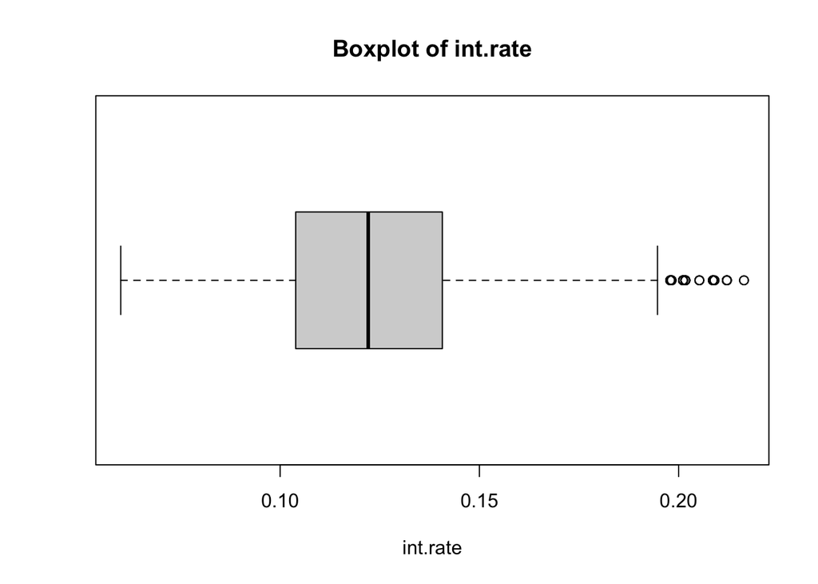

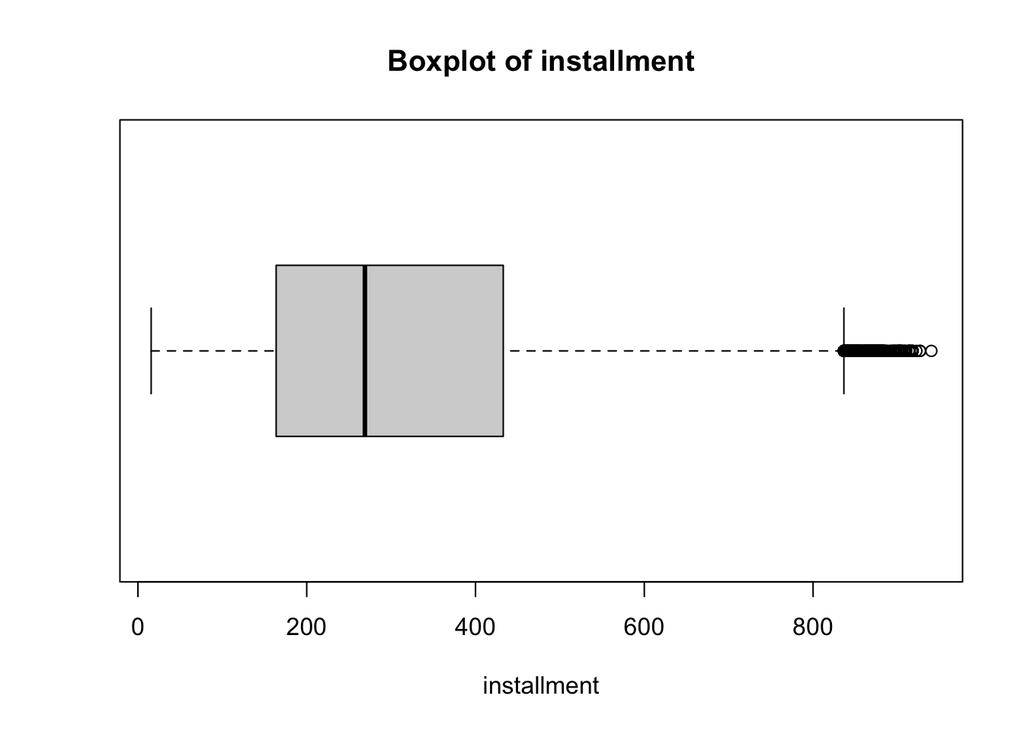

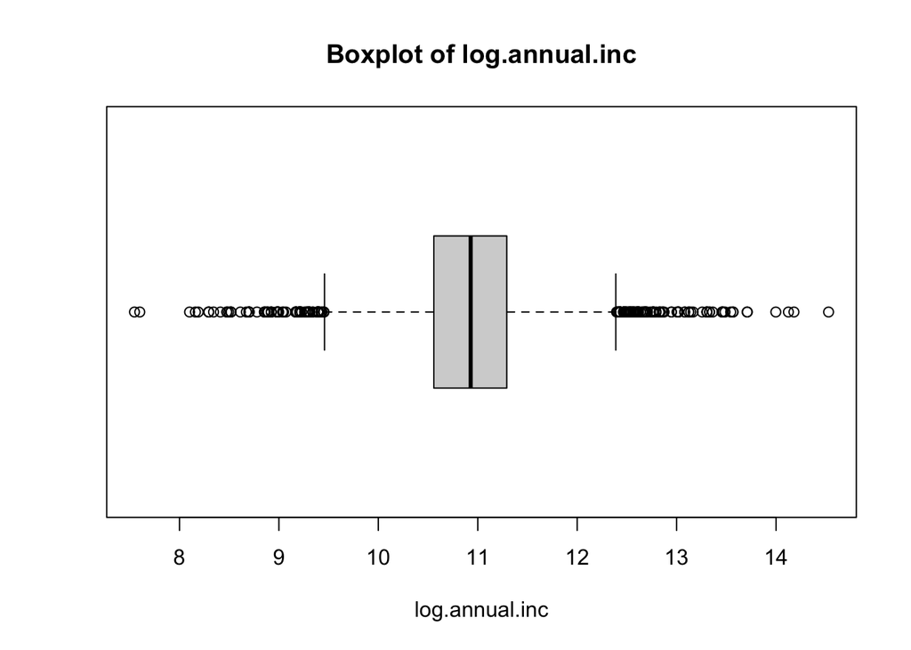

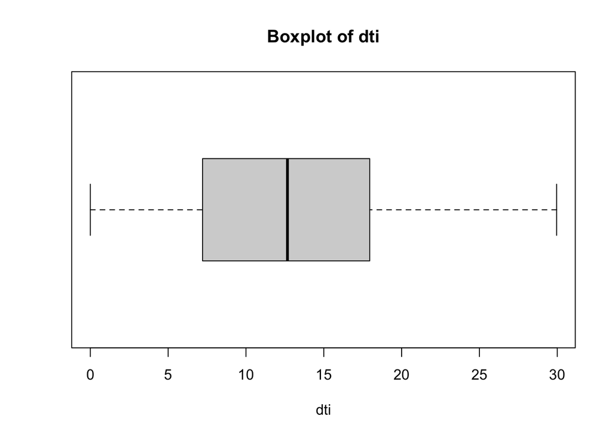

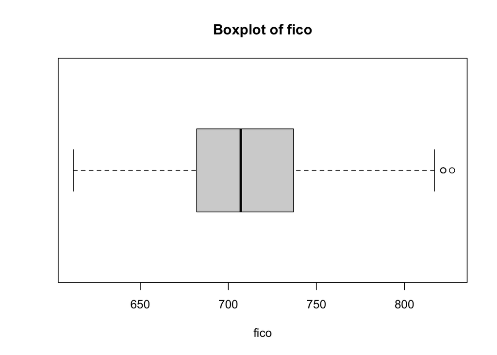

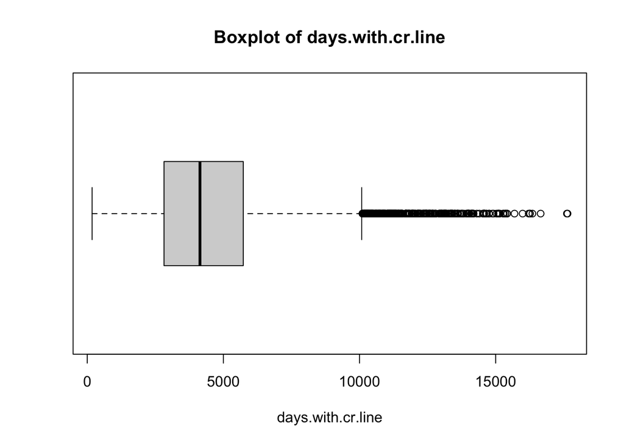

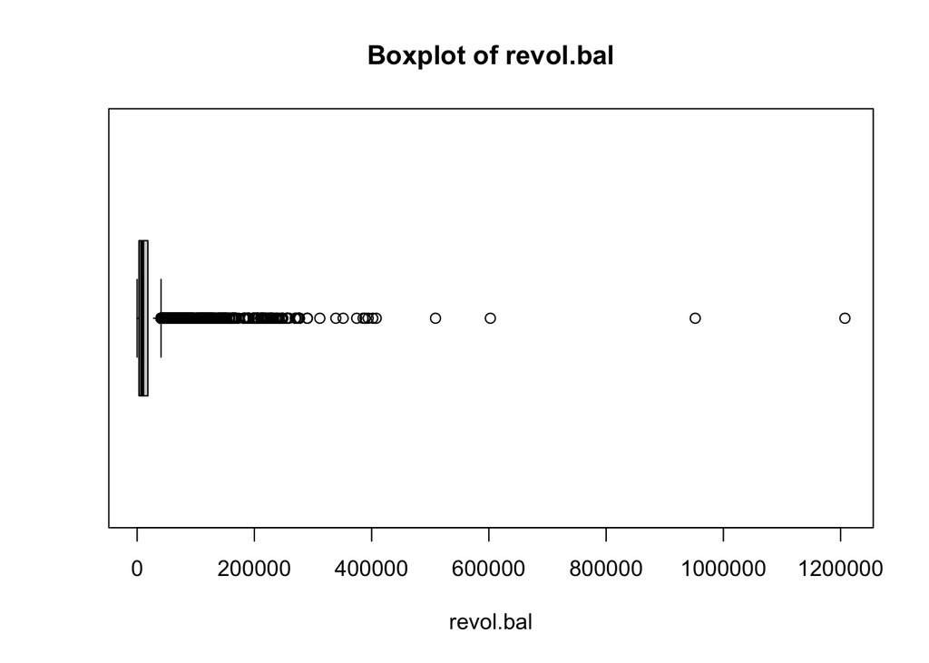

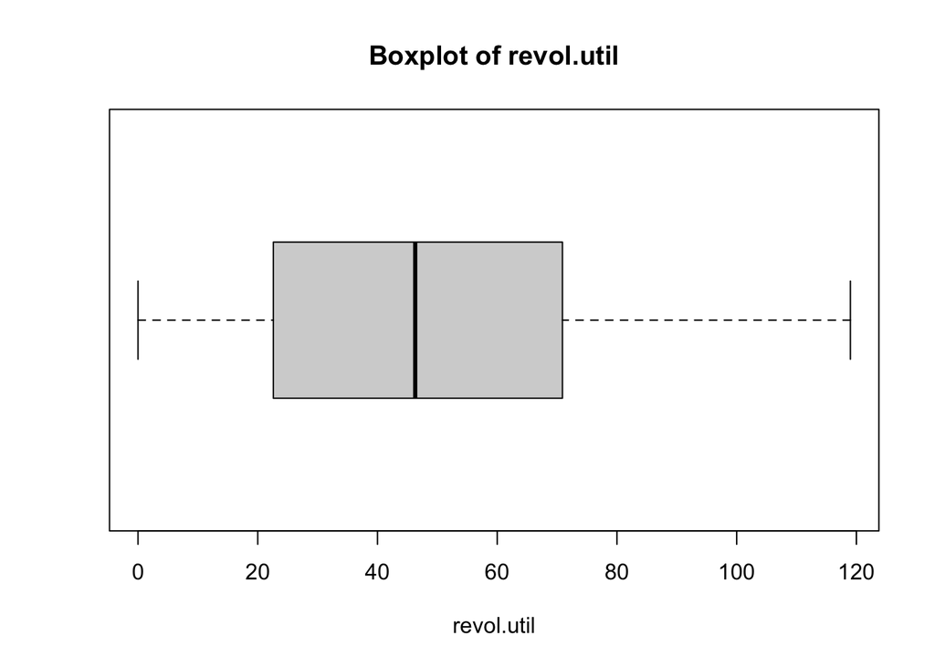

```r
# Create boxplot for each numeric variable
for (col in num_cols) {
  boxplot(df[[col]], main = paste("Boxplot of", col), xlab = col,
          horizontal = TRUE)
}
```

To visualize the distribution of each numeric variable, I generated horizontal boxplots for all columns in num_cols. These plots highlight the presence of extreme values, such as the wide spread in revol.bal, which ranges from 0 to 1207359, and the long right‑tail in days.with.cr.line, extending up to 17639.95833 days. Variables like int.rate and dti show much tighter spreads, with medians around 0.1221 and 12.665, respectively. The boxplots confirm that several predictors are skewed and contain outliers, which is expected in financial data and helps explain why tree‑based models often perform well on this dataset.

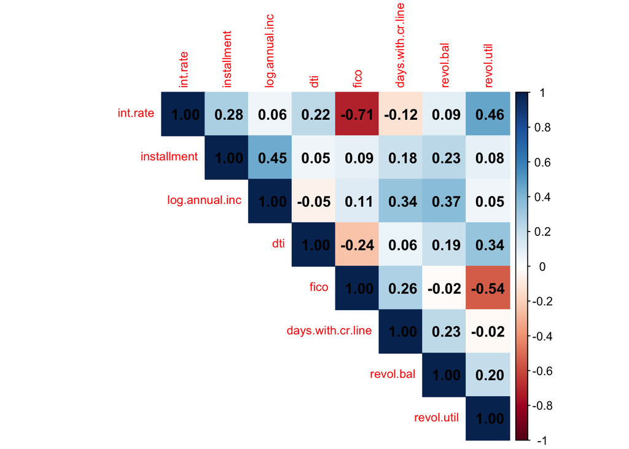

```r
# Create and display correlation matrix
cor_matrix <- cor(df[, num_cols], use = "complete.obs")
corrplot(cor_matrix, method = "color", type = "upper", tl.cex = 0.8, addCoef.col = "black")
```

```r
# Fit linear model on numeric predictors and use VIF to assess multicollinearity
lm_model <- lm(int.rate ~ ., data = df[, c("int.rate", setdiff(num_cols, "int.rate"))])
vif(lm_model)
```

```
##       installment    log.annual.inc               dti              fico
##          1.276579          1.512121          1.193564          1.589946
## days.with.cr.line         revol.bal        revol.util
##          1.243776          1.266662          1.594999
```

The correlation matrix highlights several moderate relationships among the numeric predictors, such as the association between fico and revol.util (-0.541) and between int.rate and fico (-0.715). These correlations are not strong enough to indicate redundancy, which is confirmed by the VIF values from the linear model. All VIF scores fall between 1.19 and 1.59, well below common multicollinearity thresholds. This suggests that the numeric predictors do not exhibit problematic linear dependence and can be safely included in downstream modeling without additional dimensionality reduction.

### Categorical Variables

```r
# List of columns with categorical data
cat_cols <- c("credit.policy", "purpose", "inq.last.6mths", "delinq.2yrs",
              "pub.rec", "not.fully.paid")

# Create table displaying number of unique values for categorical columns
for (col in cat_cols) {
  tab <- table(df[[col]])
  cat("Column:", col, "\n")
  cat("Unique values:", length(tab), "\n")
  cat("Most common:", names(which.max(tab)), "\n")
  cat("Count:", max(tab), "\n\n")
}
```

```
## Column: credit.policy
## Unique values: 2
## Most common: 1
## Count: 7710
##
## Column: purpose
## Unique values: 7
## Most common: debt_consolidation
## Count: 3957
##
## Column: inq.last.6mths
## Unique values: 28
## Most common: 0
## Count: 3637
##
## Column: delinq.2yrs
## Unique values: 11
## Most common: 0
## Count: 8458
##
## Column: pub.rec
## Unique values: 6
## Most common: 0
## Count: 9019
##
## Column: not.fully.paid
## Unique values: 2
## Most common: 0
## Count: 8045
```

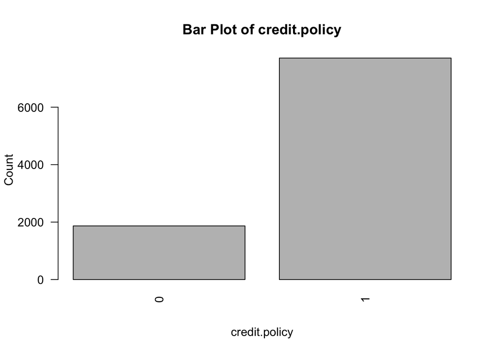

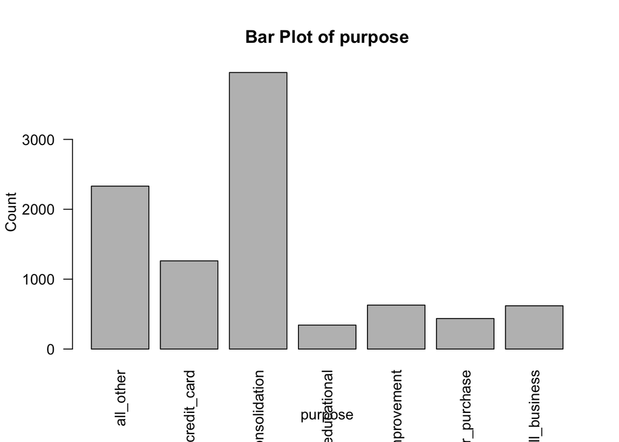

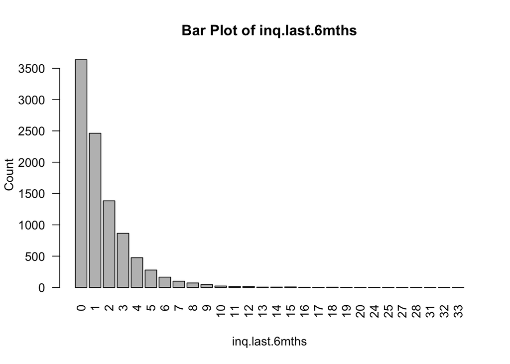

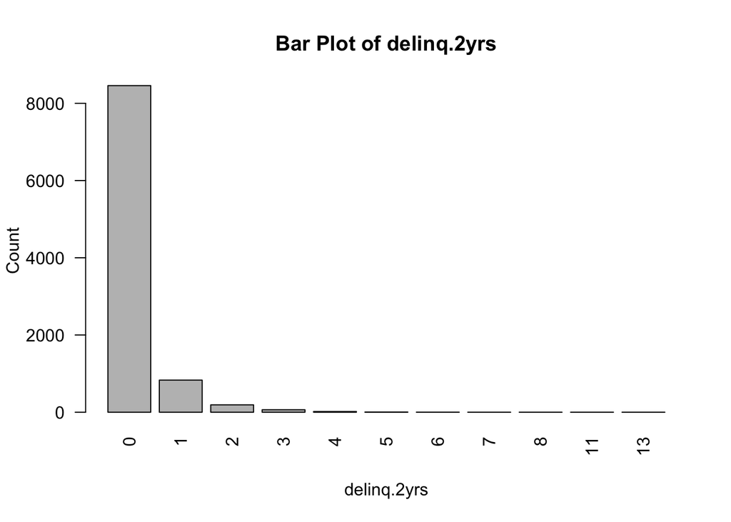

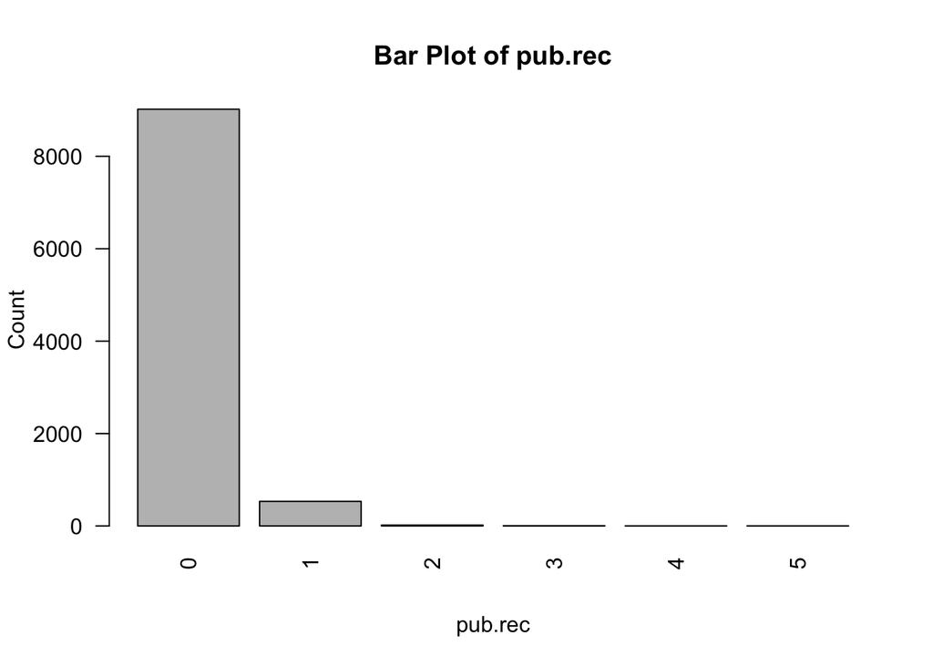

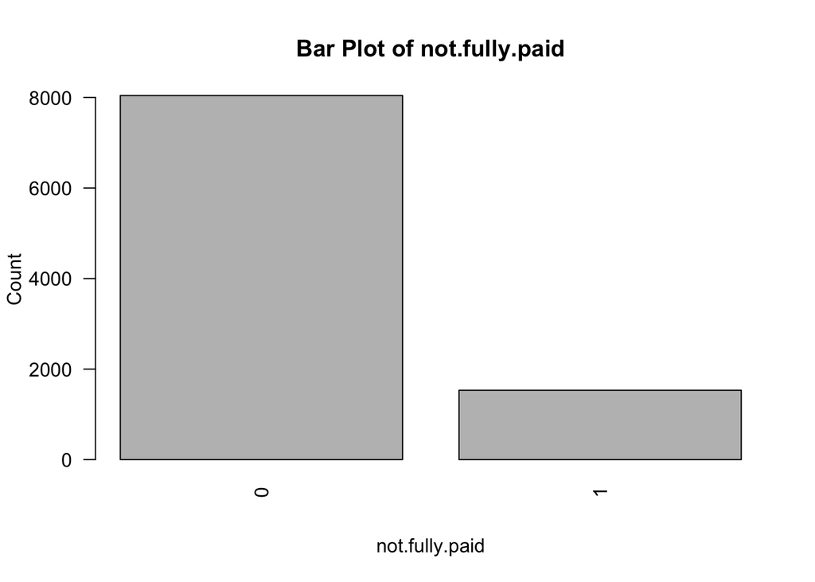

```r
# Create histogram plot for each categorical variable
for (col in cat_cols) {
  barplot(table(df[[col]]), main = paste("Bar Plot of", col), xlab = col,
          ylab = "Count", las = 2)
}
```

The barplots for the categorical variables provide a clear view of how frequently each category appears in the dataset. Several variables, such as credit.policy, delinq.2yrs, and pub.rec, are heavily dominated by a single category, reflecting the rarity of certain credit events among borrowers. The purpose variable shows a more diverse distribution, with debt consolidation being the most common loan reason. The target variable, not.fully.paid, is also highly imbalanced, with the majority of borrowers fully repaying their loans. These visualizations highlight the uneven distribution across categories and reinforce the need for techniques like SMOTE when training models sensitive to class imbalance.

### Clustering

```r
# Use only numeric columns for clustering
cluster_data <- df[, c("int.rate", "installment", "log.annual.inc",
                       "dti", "fico", "days.with.cr.line",
                       "revol.bal", "revol.util")]

# Scale numeric features
cluster_scaled <- scale(cluster_data)
```

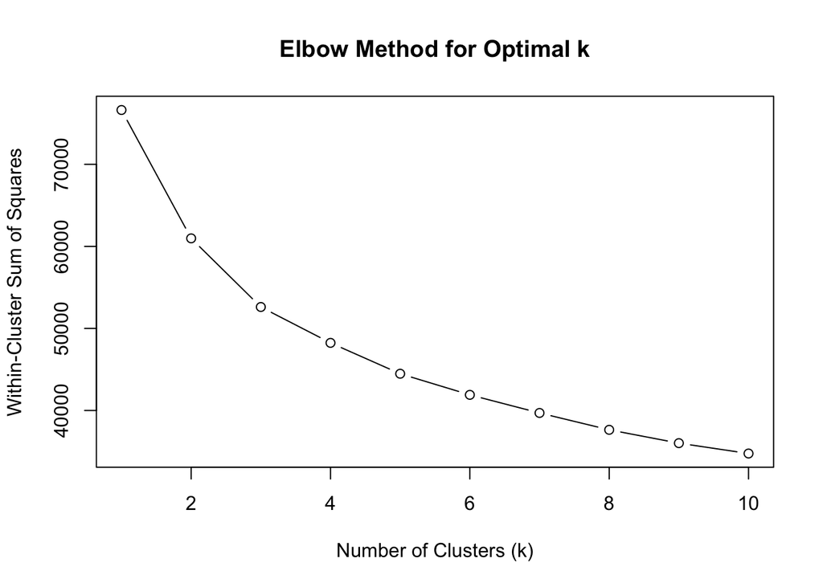

```r
# For reproducibility
set.seed(123)

# Calculate WSS across k values to support elbow method
wss <- sapply(1:10, function(k){
  kmeans(cluster_scaled, centers = k, nstart = 20)$tot.withinss
})

# Elbow plot of WSS across k values
plot(1:10, wss, type = "b",
     xlab = "Number of Clusters (k)",
     ylab = "Within-Cluster Sum of Squares",
     main = "Elbow Method for Optimal k")
```

Using k‑means on scaled numeric features, the elbow method suggested k = 3 clusters. These clusters differ meaningfully in credit score, income, and revolving balance, indicating distinct borrower profiles. This insight supports the business understanding that loan applicants are heterogeneous and may respond differently to risk models.

```r
# For reproducibility
set.seed(123)

# Run k-means with k = 3 clusters using multiple random starts
k <- 3
km_model <- kmeans(cluster_scaled, centers = k, nstart = 25)

# Add cluster labels to original data
df$cluster <- factor(km_model$cluster)
```

```r
# Cluster-wise mean summary of numeric features
aggregate(cluster_data, by = list(Cluster = df$cluster), mean)
```

```
##   Cluster  int.rate installment log.annual.inc      dti     fico
## 1       1 0.1338370    227.6074       10.62964 13.86417 685.9874
## 2       2 0.0967331    281.9096       10.95397  9.31174 749.8051
## 3       3 0.1389017    541.4371       11.46061 14.98311 701.2340
##   days.with.cr.line revol.bal revol.util
## 1          3373.640  9322.324   56.95171
## 2          5112.621  9769.185   21.93319
## 3          5969.674 41160.000   63.50767
```

```r
# Run PCA and summarize variance explained
pca_model <- prcomp(df[, num_cols], scale. = TRUE)
summary(pca_model)
```

```
## Importance of components:
##                           PC1    PC2    PC3     PC4     PC5     PC6     PC7
## Standard deviation     1.5488 1.4040 1.0164 0.85752 0.83874 0.70962 0.68111
## Proportion of Variance 0.2998 0.2464 0.1291 0.09192 0.08794 0.06294 0.05799
## Cumulative Proportion  0.2998 0.5463 0.6754 0.76731 0.85525 0.91819 0.97618
##                            PC8
## Standard deviation     0.43651
## Proportion of Variance 0.02382
## Cumulative Proportion  1.00000
```

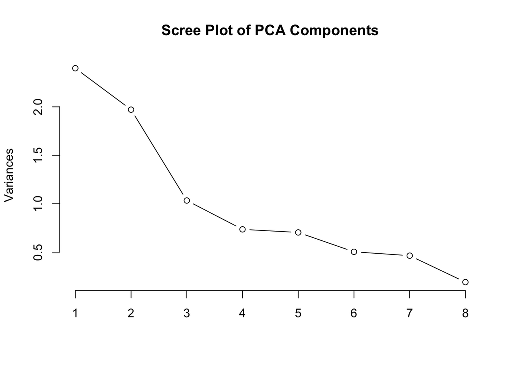

```r
# Scree plot of PCA components
plot(pca_model, type = "l", main = "Scree Plot of PCA Components")
```

## Data Preparation

### Decision Tree

```r
# Convert selected variables to factors for the decision tree model
df_dt <- df
factor_cols <- c("credit.policy", "purpose", "not.fully.paid")
df_dt[factor_cols] <- lapply(df_dt[factor_cols], as.factor)
```

### Logistic Regression

```r
# Convert selected variables to factors for the logistic regression model
df_lr <- df
df_lr$not.fully.paid <- as.factor(df_lr$not.fully.paid)
df_lr$purpose <- as.factor(df_lr$purpose)
df_lr$credit.policy <- as.factor(df_lr$credit.policy)
```

### k-Nearest Neighbors

```r
# Convert selected variables to factors for the kNN model
df_knn <- df
df_knn$not.fully.paid <- as.factor(df_knn$not.fully.paid)
df_knn$credit.policy <- as.factor(df_knn$credit.policy)
df_knn$purpose <- as.factor(df_knn$purpose)

# Generate one-hot encoded predictors for kNN
knn_x <- model.matrix(not.fully.paid ~ . - 1, data = df_knn)
df_knn <- data.frame(not.fully.paid = df_knn$not.fully.paid, knn_x)
```

```r
# Convert selected variables to factors for the kNN model
df_knn$not.fully.paid <- as.factor(df_knn$not.fully.paid)
```

To prepare the data for modeling, I created three separate training datasets tailored to each algorithm family. Decision Trees and Random Forests require categorical variables as factors, Logistic Regression requires dummy‑encoded categorical variables and standardized numeric features, and kNN requires full numeric matrices with consistent scaling. This ensures that each model receives data in the format that maximizes its performance and stability.

### Split Training/Testing Data

```r
# For reproducibility
set.seed(123)

# Create Train/Test split
train_index <- createDataPartition(df$not.fully.paid, p = 0.8, list = FALSE)

train_dt  <- df_dt[train_index, ]
test_dt   <- df_dt[-train_index, ]

train_lr  <- df_lr[train_index, ]
test_lr   <- df_lr[-train_index, ]

train_knn <- df_knn[train_index, ]
test_knn  <- df_knn[-train_index, ]
```

An 80/20 split was used to divide the data into training and testing sets. This ratio provides a strong balance between model learning and unbiased evaluation. Allocating 80% of the data to training ensures that each model—Decision Tree, Logistic Regression, and kNN—has enough observations to capture meaningful patterns, especially given the class imbalance in the target variable.

```r
### Logistic Regression Scaling
num_cols_lr <- names(train_lr)[sapply(train_lr, is.numeric) &
                              names(train_lr) != "not.fully.paid"]

train_means_lr <- sapply(train_lr[num_cols_lr], mean)
train_sds_lr   <- sapply(train_lr[num_cols_lr], sd)

train_lr[num_cols_lr] <- scale(train_lr[num_cols_lr],
                               center = train_means_lr,
                               scale = train_sds_lr)

test_lr[num_cols_lr]  <- scale(test_lr[num_cols_lr],
                               center = train_means_lr,
                               scale = train_sds_lr)


### kNN Scaling
num_cols_knn <- names(train_knn)[sapply(train_knn, is.numeric) &
                                 names(train_knn) != "not.fully.paid"]

train_means_knn <- sapply(train_knn[num_cols_knn], mean)
train_sds_knn   <- sapply(train_knn[num_cols_knn], sd)

train_knn[num_cols_knn] <- scale(train_knn[num_cols_knn],
                                 center = train_means_knn,
                                 scale = train_sds_knn)

test_knn[num_cols_knn]  <- scale(test_knn[num_cols_knn],
                                 center = train_means_knn,
                                 scale = train_sds_knn)
```

Scaling was applied to the numeric predictors for both Logistic Regression and k‑Nearest Neighbors because these models are sensitive to differences in feature magnitude. Logistic Regression uses gradient‑based optimization, which converges more reliably when predictors share a common scale. kNN relies directly on distance calculations, so unscaled variables with large numeric ranges would dominate the distance metric and distort classification.

```r
# For reproducibility
set.seed(123)

# Decision Tree
val_idx_dt <- createDataPartition(train_dt$not.fully.paid, p = 0.8, list = FALSE)
train_dt_sub <- train_dt[val_idx_dt, ]
val_dt       <- train_dt[-val_idx_dt, ]

# Logistic Regression
val_idx_lr <- createDataPartition(train_lr$not.fully.paid, p = 0.8, list = FALSE)
train_lr_sub <- train_lr[val_idx_lr, ]
val_lr       <- train_lr[-val_idx_lr, ]

# kNN
val_idx_knn <- createDataPartition(train_knn$not.fully.paid, p = 0.8, list = FALSE)
train_knn_sub <- train_knn[val_idx_knn, ]
val_knn       <- train_knn[-val_idx_knn, ]
```

A separate validation split was created for each modeling approach to support hyperparameter tuning without touching the final test set. Using an 80% subset of the training data for model fitting and the remaining 20% for validation allows each algorithm—Decision Tree, Logistic Regression, and kNN—to be tuned fairly and independently.

### Class Imbalance

```r
# Training set balance
prop.table(table(train_lr$not.fully.paid))
```

```
##
##         0         1
## 0.8389665 0.1610335
```

```r
# Testing set balance
prop.table(table(test_lr$not.fully.paid))
```

```
##
##         0         1
## 0.8438642 0.1561358
```

The class distribution in the training set shows that 0.839 of observations are fully paid and 0.161 are not fully paid, while the test set has a nearly identical split of 0.844 and 0.156, respectively. Because createDataPartition preserves class proportions, both sets maintain the original imbalance of the target variable. This consistency ensures that model evaluation reflects real‑world conditions and highlights the need for imbalance‑aware techniques such as SMOTE and threshold tuning.

```r
# For reproducibility
set.seed(123)

# Create preprocessing recipe that one‑hot encodes factors and oversamples the minority class using SMOTE
smote_recipe <- recipe(not.fully.paid ~ ., data = train_lr_sub) %>%
  step_dummy(all_nominal_predictors()) %>%
  step_smote(not.fully.paid, over_ratio = 1)

# Prep the SMOTE recipe and bake the balanced training dataset
smote_prep <- prep(smote_recipe)
train_lr_smote <- bake(smote_prep, new_data = NULL)

# Apply the same preprocessing to validation and test sets
val_lr_prepped  <- bake(smote_prep, new_data = val_lr)
test_lr_prepped <- bake(smote_prep, new_data = test_lr)
```

The target variable is highly imbalanced, with only ~16% of borrowers failing to fully repay. To address this, I applied SMOTE to the Logistic Regression dataset using a preprocessing recipe. SMOTE synthetically oversamples the minority class, improving the model’s ability to detect defaults. I applied the same preprocessing steps to validation and test sets to maintain consistency and avoid data leakage.

## Single Prediction Models

### Decision Tree

```r
# Train decision tree model
dt_model <- rpart(not.fully.paid ~ ., data = train_dt, method = "class")
```

```r
# Define a sequence of cp values to test
cp_values <- seq(0.001, 0.05, by = 0.002)

# Store results
results <- data.frame(cp = cp_values, accuracy = NA)

# Loop through possible cp values
for (i in seq_along(cp_values)) {

  # Train model with current cp
  model <- rpart(not.fully.paid ~ ., data = train_dt,
                 method = "class",
                 control = rpart.control(cp = cp_values[i]))

  # Get predictions and accuracy metric
  preds <- predict(model, val_dt, type = "class")
  acc <- mean(preds == val_dt$not.fully.paid)

  # Store result
  results$accuracy[i] <- acc
}

# Store best cp and accuracy metric
best_cp <- results$cp[which.max(results$accuracy)]
best_accuracy <- max(results$accuracy)
```

```r
# Train tuned decision tree model
dt_final <- rpart(not.fully.paid ~ ., data = train_dt, method = "class",
                  control = rpart.control(cp = best_cp))
```

### Boosted Model (GBM)

```r
# For reproducibility
set.seed(123)

# Convert train target to numeric 0/1 for GBM
train_gbm <- train_dt
train_gbm$not.fully.paid <- as.numeric(as.character(train_gbm$not.fully.paid))

# Convert test target to numeric 0/1 for GBM
test_gbm <- test_dt
test_gbm$not.fully.paid <- as.numeric(as.character(test_gbm$not.fully.paid))

# Train GBM model
gbm_model <- gbm(not.fully.paid ~ ., data = train_gbm, distribution = "bernoulli",
                 n.trees = 300, interaction.depth = 3, shrinkage = 0.05,
                 n.minobsinnode = 10, verbose = FALSE)
```

```r
# Get GBM probs and convert to predictions
gbm_probs <- predict(gbm_model, test_gbm, type = "response", n.trees = 300)
gbm_pred <- factor(ifelse(gbm_probs > 0.5, 1, 0), levels = c(0,1))
```

### Logistic Regression

```r
# Train logisitic regrssion model
lr_model <- glm(not.fully.paid ~ ., data = train_lr, family = binomial)
```

```r
# List of possible thresholds and results dataframe
thresholds <- seq(0.05, 0.95, by = 0.05)
lr_results <- data.frame(threshold = thresholds, F1 = NA)

# Get probabilities from LR model
probs <- predict(lr_model, val_lr, type = "response")

# Loop through possible thresholds
for (i in seq_along(thresholds)) {

  # Evaluate each threshold by converting probabilities to class predictions
  t <- thresholds[i]
  preds <- ifelse(probs > t, 1, 0)

  # Create confusion matrix
  cm <- confusionMatrix(
    factor(preds, levels = c(0, 1)),
    factor(val_lr$not.fully.paid, levels = c("0", "1")),
    positive = "1"
  )

  # Calculate and store F1 metric
  precision <- cm$byClass["Precision"]
  recall <- cm$byClass["Recall"]
  lr_results$F1[i] <- 2 * precision * recall / (precision + recall)
}

# Save best threshold
best_thresh_lr <- lr_results$threshold[which.max(lr_results$F1)]
```

```r
# Train final logisitic regression model
lr_final <- glm(not.fully.paid ~ ., data = train_lr, family = binomial)
```

### Logistic Regression (SMOTE)

```r
# Train logistic regression SMOTE model
lr_smote_model <- glm(not.fully.paid ~ ., data = train_lr_smote, family = binomial)
```

```r
# List of possible thresholds and results dataframe
thresholds <- seq(0.05, 0.95, by = 0.05)
lr_smote_results <- data.frame(threshold = thresholds, accuracy = NA)

# Get probabilities from LR SMOTE model
probs <- predict(lr_smote_model, val_lr_prepped, type = "response")

# Loop through possible thresholds
for (i in seq_along(thresholds)) {

  # Evaluate each threshold by converting probabilities to class predictions
  t <- thresholds[i]
  preds <- ifelse(probs > t, 1, 0)

  # Compute and save accuracies
  acc <- mean(preds == val_lr_prepped$not.fully.paid)
  lr_smote_results$accuracy[i] <- acc
}

best_thresh_smote <- lr_smote_results$threshold[which.max(lr_smote_results$accuracy)]
```

```r
# Get probabilities and convert to predictions
lr_smote_probs <- predict(lr_smote_model, test_lr_prepped, type = "response")
lr_smote_pred <- ifelse(lr_smote_probs > best_thresh_smote, 1, 0)
lr_smote_pred <- factor(lr_smote_pred, levels = c(0,1))
```

### k-Nearest Neighbors

```r
# Extract kNN predictor matrix and align test predictors to the exact same feature set
train_x <- train_knn[, !(names(train_knn) %in% "not.fully.paid")]
test_x <- test_knn[, names(train_x)]
val_x <- val_knn[, names(train_x)]
```

```r
# K-values and results dataframe
k_values <- seq(3, 19, by = 2)
knn_results <- data.frame(k = k_values, F1 = NA)

# Loop through k-values
for (i in seq_along(k_values)) {

  # Evaluate each k-value by getting predictions
  k <- k_values[i]
  preds <- knn(train = train_x, test = val_x, cl = train_knn$not.fully.paid, k = k)

  # Create confusion matrix
  cm <- confusionMatrix(preds, val_knn$not.fully.paid, positive = "1")

  # Caluculate and save F1 score
  precision <- cm$byClass["Precision"]
  recall <- cm$byClass["Recall"]
  knn_results$F1[i] <- 2 * precision * recall / (precision + recall)
}

# Save best k-value
best_k <- knn_results$k[which.max(knn_results$F1)]
```

```r
# Train tuned KNN model
test_x <- test_knn[, names(train_x)]
knn_pred <- knn(train = train_x, test = test_x, cl = train_knn$not.fully.paid, k = best_k)
```

### Evaluate Models

```r
# Decision Tree
dt_pred <- predict(dt_final, test_dt, type = "class")

# Logistic Regression
lr_probs <- predict(lr_final, test_lr, type = "response")
lr_pred <- ifelse(lr_probs > best_thresh_lr, 1, 0)
lr_pred <- factor(lr_pred, levels = c(0, 1))
```

```r
# Function that calculates accuracy, precision, recall, and F1 score
get_metrics <- function(pred, actual) {
  pred <- factor(pred, levels = c("0", "1"))
  actual <- factor(actual, levels = c("0", "1"))
  cm <- confusionMatrix(pred, actual, positive = "1")
  precision <- cm$byClass["Precision"]
  recall <- cm$byClass["Recall"]
  f1 <- 2 * precision * recall / (precision + recall)
  c(Accuracy = cm$overall["Accuracy"], Precision = precision, Recall = recall, F1 = f1)
}
```

```r
# Create accuracy table
results_table <- rbind(
  DecisionTree = get_metrics(dt_pred, test_dt$not.fully.paid),
  LogisticRegression = get_metrics(lr_pred, test_lr$not.fully.paid),
  SMOTE_Logistic = get_metrics(lr_smote_pred, test_lr$not.fully.paid),
  GBM = get_metrics(gbm_pred, factor(test_gbm$not.fully.paid, levels = c(0, 1))),
  kNN = get_metrics(knn_pred, test_knn$not.fully.paid)
)

knitr::kable(as.data.frame(results_table), digits = 4)
```

|  | Accuracy.Accuracy | Precision.Precision | Recall.Recall | F1.Precision |
| --- | --- | --- | --- | --- |
| DecisionTree | 0.8251 | 0.3163 | 0.1037 | 0.1562 |
| LogisticRegression | 0.5833 | 0.2267 | 0.6923 | 0.3416 |
| SMOTE_Logistic | 0.8439 | 0.5000 | 0.0067 | 0.0132 |
| GBM | 0.8460 | 0.5909 | 0.0435 | 0.0810 |
| kNN | 0.8073 | 0.2603 | 0.1271 | 0.1708 |

The performance comparison across the individual models shows substantial variation in how each algorithm handles the imbalanced default prediction task. The Decision Tree achieves an accuracy of 0.8251, but its recall of 0.1037 indicates that it struggles to identify positive cases. Logistic Regression performs much better on recall, reaching 0.6923, and produces the strongest F1 score at 0.3416, reflecting a more balanced trade‑off between precision and sensitivity. The SMOTE‑adjusted Logistic Regression model increases precision to 0.5, but its recall drops sharply to 0.0067, showing that oversampling alone does not guarantee improved minority‑class detection. GBM delivers the highest accuracy at 0.846, though its recall remains low, while kNN provides a moderate balance with recall of 0.1271 and an F1 score of 0.1708. Overall, Logistic Regression offers the most effective balance among the single models, particularly in identifying default cases.

## Homogenous Ensembles

To improve predictive stability, I constructed homogeneous ensembles for Logistic Regression, kNN, and Random Forest. Each ensemble uses bootstrap sampling to generate multiple base learners and averages their predictions. This reduces variance and often improves minority‑class detection. Hyperparameters were tuned using validation F1 scores.

### Random Forest

```r
# Define possible mtry values
mtry_values <- seq(2, ncol(train_dt) - 1, by = 2)

# Store results
rf_tune_results <- data.frame(mtry = mtry_values, F1 = NA)

# Loop through mtry values
for (i in seq_along(mtry_values)) {

  # For reproducibility
  set.seed(123)

  # Build RF model
  model <- randomForest(not.fully.paid ~ ., data = train_dt, ntree = 500,
                        mtry = mtry_values[i])

  # Predict on validation set
  preds <- predict(model, val_dt, type = "class")

  # Compute F1 on validation
  actual <- factor(val_dt$not.fully.paid, levels = c("0", "1"))
  preds  <- factor(preds, levels = c("0", "1"))
  cm <- confusionMatrix(preds, actual, positive = "1")
  precision <- cm$byClass["Precision"]
  recall    <- cm$byClass["Recall"]
  f1        <- 2 * (precision * recall) / (precision + recall)

  # Store results
  rf_tune_results$F1[i] <- f1
}

# Best mtry based on validation F1
best_mtry <- rf_tune_results$mtry[which.max(rf_tune_results$F1)]
best_f1   <- max(rf_tune_results$F1)
```

```r
# Train final Random Forest with best mtry
rf_final_he <- randomForest(not.fully.paid ~ ., data = train_dt, ntree = 500,
                            mtry = best_mtry)

# Final predictions
rf_ensemble_pred <- predict(rf_final_he, test_dt, type = "class")
```

### Logistic Regression

```r
# For reproducibility
set.seed(123)

# Set ensemble size, store training size, and create matrix to hold predictions
n_models <- 50
n_train_lr <- nrow(train_lr)
lr_matrix <- matrix(NA, nrow = nrow(test_lr), ncol = n_models)

# Loop through all models
for (i in 1:n_models) {

  # Draw a bootstrap sample from the training data to create one LR ensemble dataset
  boot_index <- sample(1:n_train_lr, replace = TRUE)
  boot_data <- train_lr[boot_index, ]

  # Train LR on the bootstrap data and save model predicted probabilities
  model <- glm(not.fully.paid ~ ., data = boot_data, family = binomial)
  lr_matrix[, i] <- predict(model, test_lr, type = "response")
}

# Get average probability and create predictions
lr_avg_probs <- rowMeans(lr_matrix)
lr_ensemble_pred <- factor(ifelse(lr_avg_probs > 0.5, 1, 0), levels = c(0, 1))
```

```r
# List of thresholds and results dataframe
thresholds <- seq(0.05, 0.95, by = 0.05)
lr_results <- data.frame(threshold = thresholds, F1 = NA)

# Compute validation probabilities for tuning
val_probs <- rowMeans(replicate(n = 20,
    {
      # Draw a bootstrap sample from the training data to create one LR ensemble dataset
      boot_index <- sample(1:n_train_lr, replace = TRUE)
      boot_data <- train_lr[boot_index, ]

      # Train LR on the bootstrap data and save model predicted probabilities
      model <- glm(not.fully.paid ~ ., data = boot_data, family = binomial)
      predict(model, val_lr, type = "response")
    }
  )
)

# Loop through thresholds
for (i in seq_along(thresholds)) {

  t <- thresholds[i]

  # Convert probabilities to class labels, then convert to factor
  preds <- ifelse(val_probs > t, 1, 0)
  preds <- factor(preds, levels = c(0, 1))

  # Get confusion matrix
  cm <- confusionMatrix(preds, val_lr$not.fully.paid, positive = "1")

  # Calculate F1 score and store
  precision <- cm$byClass["Precision"]
  recall <- cm$byClass["Recall"]
  f1 <- 2 * (precision * recall) / (precision + recall)

  lr_results$F1[i] <- f1
}

# Save best threshold
best_thresh_lr_he <- lr_results$threshold[which.max(lr_results$F1)]
```

```r
# Get final predictions
lr_ensemble_pred <- ifelse(lr_avg_probs > best_thresh_lr_he, 1, 0)
lr_ensemble_pred <- factor(lr_ensemble_pred, levels = c(0, 1))
```

### k-Nearest Neighbors

```r
# For reproducibility
set.seed(123)

# Set ensemble size, store training size, and create matrix to hold predictions
n_models <- 20
n_train_knn <- nrow(train_knn)
preds_matrix <- matrix(NA, nrow = nrow(test_knn), ncol = n_models)

# Loop through all models
for (i in 1:n_models) {

  # Draw a bootstrap sample from the training data to create one LR ensemble dataset
  boot_index <- sample(1:n_train_knn, replace = TRUE)
  boot_data <- train_knn[boot_index, ]

  # Split bootstrap sample into predictor matrix and target vector for kNN model
  boot_x <- boot_data[, !(names(boot_data) %in% "not.fully.paid")]
  boot_y <- boot_data$not.fully.paid

  # Store this kNN model’s predictions in the ensemble matrix
  preds_matrix[, i] <- as.numeric(knn(train = boot_x, test = test_x, cl = boot_y, k = best_k)) - 1
}
```

```r
# Loop through possible k-values
for (j in seq_along(k_values)) {

  k <- k_values[j]

  # Matrix to store numeric predictions
  preds_matrix <- matrix(NA, nrow = nrow(val_knn), ncol = n_models)

  # Loop through models
  for (i in 1:n_models) {

    # Bootstrap sample
    boot_index <- sample(1:n_train_knn, replace = TRUE)
    boot_data  <- train_knn[boot_index, ]

    train_x <- boot_data[, !(names(boot_data) %in% "not.fully.paid")]
    train_y <- boot_data$not.fully.paid

    # Validation feature matrix must match training columns
    val_x <- val_knn[, names(train_x)]

    # Store this kNN model’s predictions in the ensemble matrix
    preds_matrix[, i] <- as.numeric(knn(train = train_x, test = val_x, cl = train_y, k = k)) - 1
  }

  # Probability averaging instead of majority vote
  avg_prob <- rowMeans(preds_matrix)
  final_preds <- ifelse(avg_prob > 0.5, 1, 0)

  # Evaluate F1 on validation set
  actual <- factor(val_knn$not.fully.paid, levels = c("0", "1"))
  preds  <- factor(final_preds,           levels = c("0", "1"))

  cm <- confusionMatrix(preds, actual, positive = "1")

  precision <- cm$byClass["Precision"]
  recall    <- cm$byClass["Recall"]
  f1        <- 2 * (precision * recall) / (precision + recall)

  # Store F1 score
  knn_results$F1[j] <- f1
}

# Best k based on validation F1
best_k <- knn_results$k[which.max(knn_results$F1)]
```

```r
# Set ensemble size and create matrix to hold predictions
n_models <- 20
preds_matrix <- matrix(NA, nrow = nrow(test_knn), ncol = n_models)

# Loop through all models
for (i in 1:n_models) {

  # Draw a bootstrap sample from the training data to create one LR ensemble dataset
  boot_index <- sample(1:n_train_knn, replace = TRUE)
  boot_data  <- train_knn[boot_index, ]

  # Split bootstrap sample into predictor matrix and target vector for kNN model
  train_x <- boot_data[, !(names(boot_data) %in% "not.fully.paid")]
  train_y <- boot_data$not.fully.paid

  preds_matrix[, i] <- knn(train = train_x, test = test_x, cl = train_y, k = best_k)
}

# Convert to numeric probabilities ONLY
knn_probs <- rowMeans(preds_matrix == "1")
```

```r
# Final predictions
knn_final_preds <- ifelse(knn_probs > 0.5, 1, 0)
knn_ensemble_pred <- factor(knn_final_preds, levels = c(0,1))
```

### Evaluate Models

```r
# Create accuracy table for homogenous ensembles
ensemble_results <- rbind(
  RandomForest = get_metrics(rf_ensemble_pred, test_dt$not.fully.paid),
  LogisticEnsemble = get_metrics(lr_ensemble_pred, test_lr$not.fully.paid),
  kNNEnsemble = get_metrics(knn_ensemble_pred, test_knn$not.fully.paid))

ensemble_results <- as.data.frame(ensemble_results)
knitr::kable(ensemble_results, digits = 4)
```

|  | Accuracy.Accuracy | Precision.Precision | Recall.Recall | F1.Precision |
| --- | --- | --- | --- | --- |
| RandomForest | 0.8460 | 0.6429 | 0.0301 | 0.0575 |
| LogisticEnsemble | 0.5843 | 0.2260 | 0.6856 | 0.3400 |
| kNNEnsemble | 0.1843 | 0.1446 | 0.8595 | 0.2476 |

The ensemble comparison shows clear differences in how each method balances precision and recall. The Random Forest ensemble achieves the highest accuracy at 0.846, but its recall remains very low at 0.0301, indicating that it rarely identifies positive cases. The Logistic Regression ensemble provides a more balanced profile, with a substantially higher recall of 0.6856 and the strongest F1 score at 0.34, though at the cost of reduced accuracy. The kNN ensemble shows the highest recall at 0.8595, but its accuracy drops to 0.1843, reflecting a tendency to over‑predict the minority class. Overall, the Logistic Regression ensemble provides the best trade‑off between identifying defaults and maintaining reasonable predictive stability.

## Heterogenous Ensembles

Finally, I built three heterogeneous ensembles that blend predictions from different model families. Weighted probability averaging was used, with weights tuned on the validation set to maximize F1. These ensembles combine complementary strengths: Logistic Regression’s recall, Random Forest’s accuracy, and kNN’s sensitivity to local structure. This approach often outperforms any single model.

### Model 1

```r
# Align validation predictors for kNN, compute LR/RF validation probabilities,
val_x <- val_knn[, names(train_x)]
val_lr_probs <- predict(lr_final, val_lr, type = "response")
val_rf_probs <- predict(rf_final_he, val_dt, type = "prob")[, "1"]

# Create matrix to store 20 kNN bootstrap predictions
val_knn_matrix <- matrix(NA, nrow = nrow(val_knn), ncol = 20)

for (i in 1:20) {

  # Draw a bootstrap sample of the kNN training data
  boot_index <- sample(1:nrow(train_knn), replace = TRUE)
  boot_data <- train_knn[boot_index, ]

  # Split bootstrap kNN sample into predictors (X) and target (y)
  boot_x <- boot_data[, !(names(boot_data) %in% "not.fully.paid")]
  boot_y <- boot_data$not.fully.paid

  # Generate this bootstrap kNN model’s validation predictions
  val_knn_matrix[, i] <- as.numeric(knn(train = boot_x, test = val_x, cl = boot_y, k = best_k)) - 1
}

# Get KNN validation probabilities
val_knn_probs <- rowMeans(val_knn_matrix)
```

```r
# Create list of ensemble weights
weights <- seq(0, 1, by = 0.05)

# Create grid of all weight combinations for LR/RF/kNN and initialize F1 column
results <- expand.grid(w_lr  = weights, w_rf  = weights, w_knn = weights)
results$F1 <- NA

# Set validation target as factor
actual <- factor(val_lr$not.fully.paid, levels = c("0","1"))

for (i in 1:nrow(results)) {

  # Extract the LR, RF, and kNN weights for this row of the grid
  w1 <- results$w_lr[i]
  w2 <- results$w_rf[i]
  w3 <- results$w_knn[i]

  # Normalize weights
  s <- w1 + w2 + w3
  if (s == 0) next
  w1 <- w1 / s; w2 <- w2 / s; w3 <- w3 / s

  # Weighted probability
  blended <- w1*val_lr_probs + w2*val_rf_probs + w3*val_knn_probs

  # Convert to predictions
  preds <- ifelse(blended > 0.5, 1, 0)
  preds <- factor(preds, levels = c("0","1"))

  # Calculate and store F1 score
  cm <- confusionMatrix(preds, actual, positive = "1")
  precision <- cm$byClass["Precision"]
  recall    <- cm$byClass["Recall"]
  f1        <- 2*(precision*recall)/(precision+recall)

  results$F1[i] <- f1
}

# Get weights with best F1 score
best_row <- results[which.max(results$F1), ]
```

```r
# Test probabilities
test_lr_probs  <- lr_avg_probs
test_rf_probs  <- predict(rf_final_he, test_dt, type = "prob")[, "1"]
test_knn_probs <- knn_probs

# Normalize weights
s <- best_row$w_lr + best_row$w_rf + best_row$w_knn
w1 <- best_row$w_lr  / s
w2 <- best_row$w_rf  / s
w3 <- best_row$w_knn / s

# Weighted probability
hetero_prob <- w1*test_lr_probs + w2*test_rf_probs + w3*test_knn_probs

# Final prediction
hetero_pred <- ifelse(hetero_prob > 0.5, 1, 0)
hetero_pred <- factor(hetero_pred, levels = c("0","1"))
```

### Model 2

```r
# Get model probabilities
val_lr_single_probs <- predict(lr_final, val_lr, type = "response")
val_knn_single_probs <- as.numeric(knn(train = train_x, test = val_x,
                                       cl = train_knn$not.fully.paid, k = best_k)) - 1

val_lr_smote_probs <- predict(lr_smote_model, val_lr_prepped, type = "response")
```

```r
# Create list of ensemble weights
weights <- seq(0, 1, by = 0.05)

# Create grid of all weight combinations for LR/KNN/SMOTE and initialize F1 column
results_single <- expand.grid(w_lr = weights, w_knn = weights, w_lr_smote = weights)
results_single$F1 <- NA

# Set validation target as factor
actual <- factor(val_lr$not.fully.paid, levels = c("0","1"))

for (i in 1:nrow(results_single)) {

  # Extract the LR, KNN, and SMOTE weights for this row of the grid
  w1 <- results_single$w_lr[i]
  w2 <- results_single$w_knn[i]
  w3 <- results_single$w_lr_smote[i]

  # Normalize weights
  s <- w1 + w2 + w3
  if (s == 0) next
  w1 <- w1 / s; w2 <- w2 / s; w3 <- w3 / s

  # Weighted probability
  blended <- w1*val_lr_single_probs + w2*val_knn_single_probs + w3*val_lr_smote_probs

  # Convert to predictions
  preds <- factor(ifelse(blended > 0.5, 1, 0), levels = c("0","1"))

  # Calculate and store F1 score
  cm <- confusionMatrix(preds, actual, positive = "1")
  precision <- cm$byClass["Precision"]
  recall    <- cm$byClass["Recall"]
  f1        <- 2*(precision*recall)/(precision+recall)

  results_single$F1[i] <- f1
}

# Get weights with best F1 score
best_row_single <- results_single[which.max(results_single$F1), ]
```

```r
# Test probabilities
test_lr_single_probs <- predict(lr_final, test_lr, type = "response")
test_knn_single_probs <- as.numeric(knn(train = train_x, test = test_x,
                                        cl = train_knn$not.fully.paid, k = best_k)) - 1

test_lr_smote_probs <- predict(lr_smote_model, test_lr_prepped, type = "response")

# Normalize weights
s <- best_row_single$w_lr + best_row_single$w_knn + best_row_single$w_lr_smote

w1 <- best_row_single$w_lr       / s
w2 <- best_row_single$w_knn      / s
w3 <- best_row_single$w_lr_smote / s

# Final blended probability
hetero_single_prob <- w1*test_lr_single_probs +
                      w2*test_knn_single_probs +
                      w3*test_lr_smote_probs

# Convert to prediction
hetero_single_pred <- factor(ifelse(hetero_single_prob > 0.5, 1, 0),
                             levels = c("0","1"))
```

### Model 3

```r
# Get model probabilities
val_lr_probs <- predict(lr_final, val_lr, type = "response")
val_rf_probs <- predict(rf_final_he, val_dt, type = "prob")[, "1"]
val_lr_smote_probs <- predict(lr_smote_model, val_lr_prepped, type = "response")
```

```r
# Create list of ensemble weights
weights <- seq(0, 1, by = 0.05)

# Create grid of all weight combinations for LR/RF/SMOTE and initialize F1 column
results_lr_rf_smote <- expand.grid(w_lr = weights, w_rf = weights, w_lr_smote = weights)
results_lr_rf_smote$F1 <- NA

# Set validation target as factor
actual <- factor(val_lr$not.fully.paid, levels = c("0","1"))

for (i in 1:nrow(results_lr_rf_smote)) {

  # Extract the LR, RF, and SMOTE weights for this row of the grid
  w1 <- results_lr_rf_smote$w_lr[i]
  w2 <- results_lr_rf_smote$w_rf[i]
  w3 <- results_lr_rf_smote$w_lr_smote[i]

  # Normalize weights
  s <- w1 + w2 + w3
  if (s == 0) next
  w1 <- w1 / s; w2 <- w2 / s; w3 <- w3 / s

  # Weighted probability
  blended <- w1*val_lr_probs + w2*val_rf_probs + w3*val_lr_smote_probs

  # Convert to predictions
  preds <- factor(ifelse(blended > 0.5, 1, 0), levels = c("0","1"))

  # Calculate and store F1 score
  cm <- confusionMatrix(preds, actual, positive = "1")
  precision <- cm$byClass["Precision"]
  recall    <- cm$byClass["Recall"]
  f1        <- 2*(precision*recall)/(precision+recall)


  results_lr_rf_smote$F1[i] <- f1
}

# Get weights with best F1 score
best_row_lr_rf_smote <- results_lr_rf_smote[which.max(results_lr_rf_smote$F1), ]
```

```r
# Test probabilities
test_lr_probs  <- predict(lr_final, test_lr, type = "response")
test_rf_probs  <- predict(rf_final_he, test_dt, type = "prob")[, "1"]
test_lr_smote_probs <- predict(lr_smote_model, test_lr_prepped, type = "response")

# Normalize weights
s <- best_row_lr_rf_smote$w_lr + best_row_lr_rf_smote$w_rf + best_row_lr_rf_smote$w_lr_smote

w1 <- best_row_lr_rf_smote$w_lr       / s
w2 <- best_row_lr_rf_smote$w_rf       / s
w3 <- best_row_lr_rf_smote$w_lr_smote / s

# Final blended probability
hetero_lr_rf_smote_prob <- w1*test_lr_probs +
                           w2*test_rf_probs +
                           w3*test_lr_smote_probs

# Convert to prediction
hetero_lr_rf_smote_pred <- factor(ifelse(hetero_lr_rf_smote_prob > 0.5, 1, 0),
                                  levels = c("0","1"))
```

This ensemble combines Logistic Regression, Random Forest, and SMOTE‑Logistic Regression because together they represent three fundamentally different modeling strategies: a linear model trained on the original data, a nonlinear tree‑based model, and a logistic model trained on a balanced dataset. These models capture different patterns in the predictors and respond differently to class imbalance, so blending their probability outputs increases diversity and improves overall robustness compared to relying on any single approach.

### Evaluate Models

```r
# Create accuracy table for all heterogenous ensembles
hetero_all_results <- rbind(
  Hetero_LR_RF_KNN = get_metrics(hetero_pred, test_lr$not.fully.paid),
  Hetero_LR_KNN_SMOTE = get_metrics(hetero_single_pred, test_lr$not.fully.paid),
  Hetero_LR_RF_SMOTE = get_metrics(hetero_lr_rf_smote_pred, test_lr$not.fully.paid))

hetero_all_results <- as.data.frame(hetero_all_results)
knitr::kable(hetero_all_results, digits = 4,
             caption = "Comparison of All Three Heterogeneous Ensembles")
```

Comparison of All Three Heterogeneous Ensembles

|  | Accuracy.Accuracy | Precision.Precision | Recall.Recall | F1.Precision |
| --- | --- | --- | --- | --- |
| Hetero_LR_RF_KNN | 0.8470 | 0.6154 | 0.0535 | 0.0985 |
| Hetero_LR_KNN_SMOTE | 0.6606 | 0.2445 | 0.5619 | 0.3408 |
| Hetero_LR_RF_SMOTE | 0.6606 | 0.2445 | 0.5619 | 0.3408 |

## Model Comparison

```r
# Create final accuracy table with all 11 models
all_model_results <- rbind(
  DecisionTree = get_metrics(dt_pred, test_dt$not.fully.paid),
  LogisticRegression = get_metrics(lr_pred, test_lr$not.fully.paid),
  SMOTE_Logistic = get_metrics(lr_smote_pred, test_lr$not.fully.paid),
  GBM = get_metrics(gbm_pred, factor(test_gbm$not.fully.paid, levels = c(0,1))),
  kNN = get_metrics(knn_ensemble_pred, test_knn$not.fully.paid),

  RandomForest_Ensemble = get_metrics(rf_ensemble_pred, test_dt$not.fully.paid),
  Logistic_Ensemble = get_metrics(lr_ensemble_pred, test_lr$not.fully.paid),
  kNN_Ensemble = get_metrics(knn_ensemble_pred, test_knn$not.fully.paid),

  Hetero_LR_RF_KNN = get_metrics(hetero_pred, test_lr$not.fully.paid),
  Hetero_LR_KNN_SMOTE = get_metrics(hetero_single_pred, test_lr$not.fully.paid),
  Hetero_LR_RF_SMOTE = get_metrics(hetero_lr_rf_smote_pred, test_lr$not.fully.paid))

all_model_results <- as.data.frame(all_model_results)

knitr::kable(all_model_results, digits = 4,
             caption = "Comparison of All Single Models, Homogeneous Ensembles, and Heterogeneous Ensembles")
```

Comparison of All Single Models, Homogeneous Ensembles, and Heterogeneous Ensembles

|  | Accuracy.Accuracy | Precision.Precision | Recall.Recall | F1.Precision |
| --- | --- | --- | --- | --- |
| DecisionTree | 0.8251 | 0.3163 | 0.1037 | 0.1562 |
| LogisticRegression | 0.5833 | 0.2267 | 0.6923 | 0.3416 |
| SMOTE_Logistic | 0.8439 | 0.5000 | 0.0067 | 0.0132 |
| GBM | 0.8460 | 0.5909 | 0.0435 | 0.0810 |
| kNN | 0.1843 | 0.1446 | 0.8595 | 0.2476 |
| RandomForest_Ensemble | 0.8460 | 0.6429 | 0.0301 | 0.0575 |
| Logistic_Ensemble | 0.5843 | 0.2260 | 0.6856 | 0.3400 |
| kNN_Ensemble | 0.1843 | 0.1446 | 0.8595 | 0.2476 |
| Hetero_LR_RF_KNN | 0.8470 | 0.6154 | 0.0535 | 0.0985 |
| Hetero_LR_KNN_SMOTE | 0.6606 | 0.2445 | 0.5619 | 0.3408 |
| Hetero_LR_RF_SMOTE | 0.6606 | 0.2445 | 0.5619 | 0.3408 |

The full comparison across all single models, homogeneous ensembles, and heterogeneous ensembles highlights the trade‑offs each approach makes when predicting loan defaults. Among the single models, Logistic Regression provides the strongest balance, with an F1 score of 0.3416 and a recall of 0.6923, while GBM achieves the highest accuracy at 0.846 but still struggles to identify positive cases. The homogeneous ensembles show similar patterns: the Random Forest ensemble reaches an accuracy of 0.846, yet its recall remains extremely low at 0.0301, whereas the Logistic Regression ensemble maintains a more balanced recall of 0.6856. The heterogeneous ensembles offer modest improvements, with the LR–RF–kNN combination achieving the highest accuracy overall at 0.847, though its recall remains limited. In contrast, the SMOTE‑based heterogeneous models improve recall to 0.5619, but their precision and accuracy decline accordingly. Overall, the results show that no single model dominates across all metrics, but Logistic Regression–based approaches consistently provide the most balanced performance in detecting defaults.